# Lab 3

ED 214B

Winter 2024

### Working Directory

```r
setwd("~/Desktop/ED214_TA_Materials/ED214B/Lab3")
```

### Importing Libraries

```r
library(readxl) # import Excel document
library(psych) # describe function
library(summarytools) # freq function
library(lmtest) # Breusch-Pagan test
library(tidyverse) # ggplot and piping operator
```

### Importing Data

```r
df <- read_excel("week2d.xlsx")
View(df)
```

## Research Question and Hypotheses

Research question: Do students who enjoy reading and have greater school satisfaction tend to do better in school?

Testable hypothesis: Does reading enjoyment (*enjoyread*) and school satisfaction (*schsat*) predict verbal test scores (*verbalscr*)?

## Data Cleaning

```r
describe(df$enjoyread)
```

```
##    vars    n   mean      sd median trimmed  mad min  max range skew kurtosis
## X1    1 3303 750.64 2629.68      3    3.26 1.48   0 9999  9999 3.23     8.45
##       se
## X1 45.76
```

```r
describe(df$schlsat)
```

```
##    vars    n   mean      sd median trimmed  mad min  max range skew kurtosis
## X1    1 3303 760.61 2626.85     14    14.5 4.45   1 9999  9998 3.23     8.45
##       se
## X1 45.71
```

```r
describe(df$verbalscr)
```

```
##    vars    n mean      sd median trimmed  mad  min  max  range skew kurtosis
## X1    1 3303  775 2622.75   29.7   29.92 3.41 18.7 9999 9980.3 3.23     8.45
##       se
## X1 45.64
```

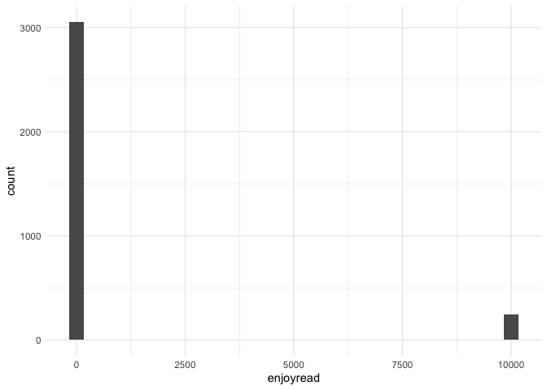

```r
df %>%
  ggplot(aes(x=enjoyread))+
  geom_histogram()+
  theme_minimal()
```

### Recode Missing Data

```r
df$enjoyread[df$enjoyread==9999] <- NA
df$schlsat[df$schlsat==9999] <- NA
df$verbalscr[df$verbalscr==9999] <- NA
```

## Plot the Recoded Data

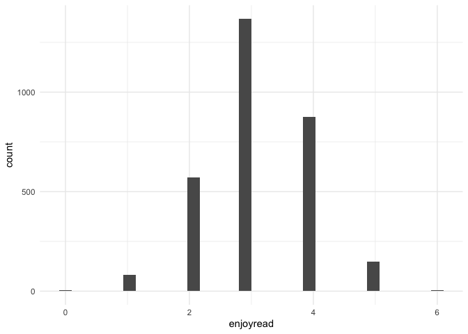

```r
df %>%
  ggplot(aes(x=enjoyread))+
  geom_histogram()+
  theme_minimal()
```

As we can see, **enjoyread** is ordinal. We’ll treat this variable as continuous in the regression model (for now). We should look at the frequency table from `summarytools` instead of the descriptive statistics from the `describe` function in the `psych` package.

```r
freq(df$enjoyread)
```

```
## Frequencies
## df$enjoyread
## Type: Numeric
##
##               Freq   % Valid   % Valid Cum.   % Total   % Total Cum.
## ----------- ------ --------- -------------- --------- --------------
##           0      4      0.13           0.13      0.12           0.12
##           1     83      2.72           2.85      2.51           2.63
##           2    573     18.75          21.60     17.35          19.98
##           3   1369     44.80          66.39     41.45          61.43
##           4    875     28.63          95.03     26.49          87.92
##           5    147      4.81          99.84      4.45          92.37
##           6      5      0.16         100.00      0.15          92.52
##        <NA>    247                               7.48         100.00
##       Total   3303    100.00         100.00    100.00         100.00
```

We should plot **enjoyread** as a bar graph because it is ordinal.

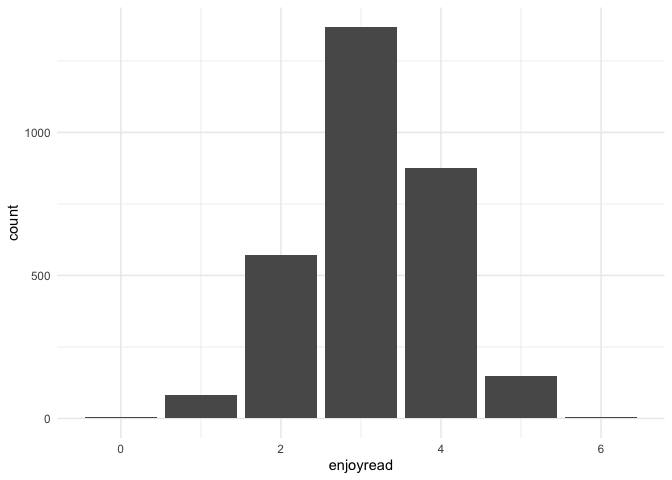

```r
df %>%
  ggplot(aes(x=enjoyread))+
  geom_bar()+
  theme_minimal()
```

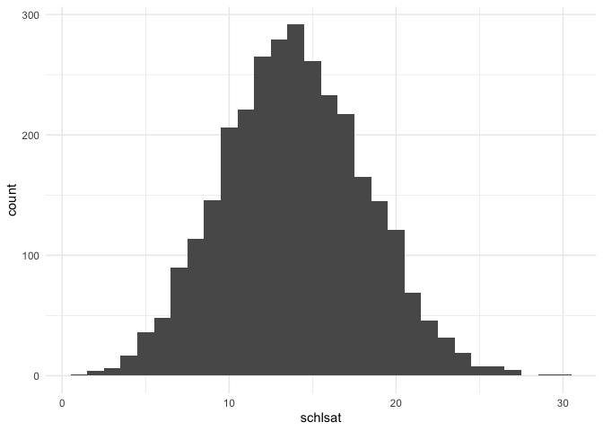

```r
df %>%
  ggplot(aes(x=schlsat))+
  geom_histogram()+
  theme_minimal()
```

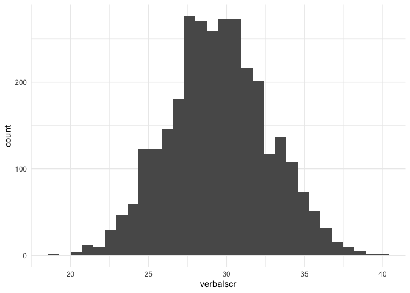

```r
df %>%
  ggplot(aes(x=verbalscr))+
  geom_histogram()+
  theme_minimal()
```

## Simple Linear Regression

```r
mod_read <- lm(verbalscr~enjoyread,data=df)
summary(mod_read)
```

```
##
## Call:
## lm(formula = verbalscr ~ enjoyread, data = df)
##
## Residuals:
##    Min     1Q Median     3Q    Max
## -4.776 -1.476 -0.004  1.452  6.324
##
## Coefficients:
##             Estimate Std. Error t value Pr(>|t|)
## (Intercept) 20.76003    0.13967  148.64   <2e-16 ***
## enjoyread    2.77199    0.04279   64.77   <2e-16 ***
## ---
## Signif. codes:  0 '***' 0.001 '**' 0.01 '*' 0.05 '.' 0.1 ' ' 1
##
## Residual standard error: 2.091 on 3054 degrees of freedom
##   (247 observations deleted due to missingness)
## Multiple R-squared:  0.5787, Adjusted R-squared:  0.5786
## F-statistic:  4196 on 1 and 3054 DF,  p-value: < 2.2e-16
```

```r
confint(mod_read)
```

```
##                 2.5 %    97.5 %
## (Intercept) 20.486178 21.033883
## enjoyread    2.688077  2.855896
```

```r
mod_sch <- lm(verbalscr~schlsat,data=df)
summary(mod_sch)
```

```
##
## Call:
## lm(formula = verbalscr ~ schlsat, data = df)
##
## Residuals:
##     Min      1Q  Median      3Q     Max
## -9.3012 -1.8017  0.0036  1.8128  9.1143
##
## Coefficients:
##             Estimate Std. Error t value Pr(>|t|)
## (Intercept) 23.87407    0.16769  142.37   <2e-16 ***
## schlsat      0.40194    0.01152   34.91   <2e-16 ***
## ---
## Signif. codes:  0 '***' 0.001 '**' 0.01 '*' 0.05 '.' 0.1 ' ' 1
##
## Residual standard error: 2.724 on 3054 degrees of freedom
##   (247 observations deleted due to missingness)
## Multiple R-squared:  0.2852, Adjusted R-squared:  0.2849
## F-statistic:  1218 on 1 and 3054 DF,  p-value: < 2.2e-16
```

```r
confint(mod_sch)
```

```
##                  2.5 %     97.5 %
## (Intercept) 23.5452851 24.2028631
## schlsat      0.3793617  0.4245186
```

## Multiple Linear Regression

```r
mlr_mod <- lm(verbalscr~enjoyread+schlsat,data=df)
summary(mlr_mod)
```

```
##
## Call:
## lm(formula = verbalscr ~ enjoyread + schlsat, data = df)
##
## Residuals:
##     Min      1Q  Median      3Q     Max
## -5.3382 -1.0554  0.0066  1.0428  5.7996
##
## Coefficients:
##              Estimate Std. Error t value Pr(>|t|)
## (Intercept) 16.730637   0.128843  129.85   <2e-16 ***
## enjoyread    2.568423   0.031584   81.32   <2e-16 ***
## schlsat      0.335431   0.006524   51.41   <2e-16 ***
## ---
## Signif. codes:  0 '***' 0.001 '**' 0.01 '*' 0.05 '.' 0.1 ' ' 1
##
## Residual standard error: 1.531 on 3053 degrees of freedom
##   (247 observations deleted due to missingness)
## Multiple R-squared:  0.7742, Adjusted R-squared:  0.7741
## F-statistic:  5235 on 2 and 3053 DF,  p-value: < 2.2e-16
```

- Controlling for school satisfaction, reading enjoyment is significant (p < .001).
- Controlling for reading enjoyment, school satisfaction is significant (p < .001).

The t-value in our MLR model is the coefficient divided by the standard error.

```r
2.568423 / 0.031584
```

```
## [1] 81.32038
```

### Confidence Intervals

```r
confint(mlr_mod)
```

```
##                  2.5 %     97.5 %
## (Intercept) 16.4780103 16.9832646
## enjoyread    2.5064952  2.6303507
## schlsat      0.3226392  0.3482235
```

- The interval has a 95% probability that it will contain the true value of $\beta_1$.

### Model Summary

- enjoyread
  - $\hat{y} = \beta_0 + \beta_1*enjoyread + \beta_2*schlsat$
  - $\hat{y} = 16.73 + 2.57*enjoyread + .34*schlsat$
  - $R^2 = .77$
  - 95% CI for enjoyread: (2.51, 2.63)
    - *Doesn’t contain 0*
  - 95% CI for schlsat: (.32, .35)
    - *Doesn’t contain 0*
  - A one unit increase in reading enjoyment is associated with a 2.57 unit difference in verbal test scores, controlling for school satisfaction.
  - A one unit increase in school satisfaction is associated with a .34 unit difference in verbal test scores, controlling for reading enjoyment.

### Plot Each Relationship

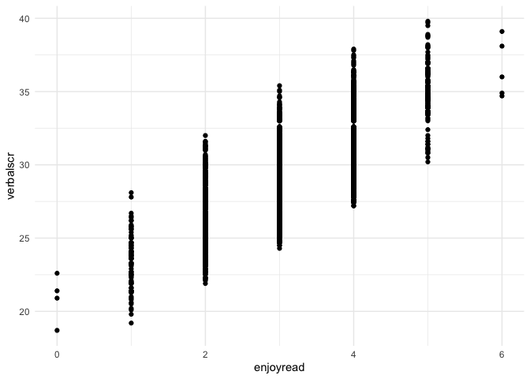

```r
df %>%
  ggplot(aes(x=enjoyread,y=verbalscr))+
  geom_point()+
  theme_minimal()
```

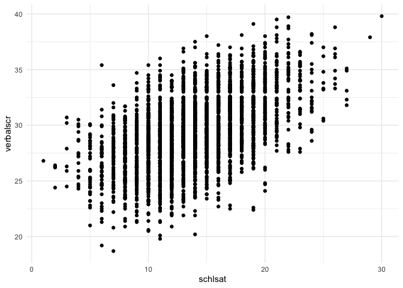

```r
df %>%
  ggplot(aes(x=schlsat,y=verbalscr))+
  geom_point()+
  theme_minimal()
```

## Diagnostic Plots for Homoscedasticity

Remember that *homoscedasticity* means that you have the same scatter.

- We want to see no relationship and a horizontal red line. This can be used to look at homoscedasticity.

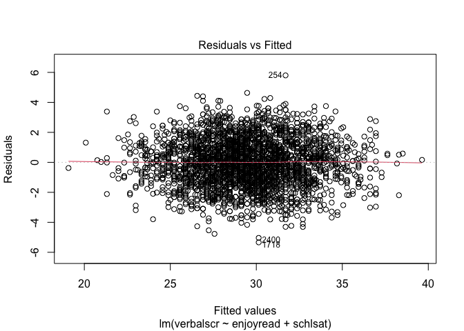

```r
plot(mlr_mod, 1)
```

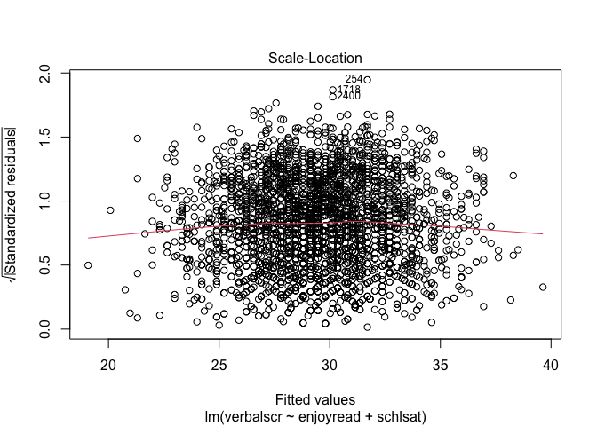

```r
plot(mlr_mod, 3)
```

We can see that the points have a pattern; thus, homoscedasticity is violated.

### Breusch-Pagan Test

We can also check homoscedasticity with the Breusch-Pagan Test. The null hypothesis for this test is that homoscedasticity is not violated.

```r
bptest(mlr_mod)
```

```
##
##  studentized Breusch-Pagan test
##
## data:  mlr_mod
## BP = 9.7436, df = 2, p-value = 0.00766
```

Our results are significant, which means we reject the null hypothesis. Homoscedasticity is indeed violated as we saw with our diagnostic plots.

## Sum of Squares

- The type of estimation that we normally use in regression to estimate the unknown parameters (i.e., the slope and the intercept) is “ordinary least squares”.
- The goal of “ordinary least squares” is to find a linear line that minimizes the “sums of squares” of the differences between the predicted outcome values ($\hat{y}$) and the observed outcome value ($y$).
- What are the sums of squares?
- Sum of squares are the sum of **squared residuals**
  - We have to square them because there are some positive and some negative residuals, so if we don’t square them, they’ll cancel out to 0. This gives us an idea of the magnitude of the amount of error in the model.
- How do we interpret this number? We have to compare it to the amount of variance that the predictor(s) explain in the outcome variable. In other words, we want to maximize the amount of variance that can be explained, and minimize the the variance that cannot be explained.

### ANOVA

```r
anova(mlr_mod)
```

```
## Analysis of Variance Table
##
## Response: verbalscr
##             Df  Sum Sq Mean Sq F value    Pr(>F)
## enjoyread    1 18346.5 18346.5  7825.8 < 2.2e-16 ***
## schlsat      1  6197.0  6197.0  2643.4 < 2.2e-16 ***
## Residuals 3053  7157.3     2.3
## ---
## Signif. codes:  0 '***' 0.001 '**' 0.01 '*' 0.05 '.' 0.1 ' ' 1
```

- In the ANOVA table, we see that the residual sum of squares is 7,157.3. Let’s replicate that.

### Sum and Square the Residuals

```r
sum(mlr_mod$residuals^2)
```

```
## [1] 7157.284
```

- For review, $R^2$ comes from the sums of squares.

$$R^2 =
\frac{SS_{regression}}{SS_{total}}$$

- $SS_{regression} = 18346.5 + 6197 = 24543.5$
- $SS_{total} = SS_{regression} + SS_{residual} = 24543.5 + 7157.3 = 31700.8$
- $R^2 = \frac{SS_{regression}}{SS_{total}} = .7742$